# Program Summary - validation.sas

### Program Summary - validation.sas

### Execution Environment

| Author: | u64352390 |
| --- | --- |
| File: | /home/u64352390/project/Midterm/validation.sas |
| SAS Platform: | Linux LIN X64 5.14.0-284.30.1.el9_2.x86_64 |
| SAS Host: | ODAWS01-USW2-2.ODA.SAS.COM |
| SAS Version: | 9.04.01M8P02222023 |
| SAS Locale: | en_US |
| Submission Time: | 11/14/2025, 1:41:04 AM |
| Browser Host: | SYN-074-062-153-097.BIZ.SPECTRUM.COM |
| User Agent: | Mozilla/5.0 (Macintosh; Intel Mac OS X 10_15_7) AppleWebKit/537.36 (KHTML, like Gecko) Chrome/142.0.0.0 Safari/537.36 |
| Application Server: | ODAMID00-USW2-2.ODA.SAS.COM |

### Code: validation.sas

libname MIDTERM "/home/u64352390/project/Midterm";

run;

/* we do not utilize PROC IMPORT since the file isn't delimited but fix-width

PROC IMPORT OUT= MIDTERM.origin

DATAFILE= "/home/u64352394/BIOSTAT203A/Midterm_Project/matched-multiple-birth-fetal-death-2016-2020.txt"

RUN; */

DATA MIDTERM.origin_main (label="Matched Multiple Birth and Fetal Death: Selected Variables");

INFILE '//home/u64352390/project/Midterm/MULTIPLES.TXT'

LRECL=157 TRUNCOVER;

/* location for specification

of format and informats */

INPUT

/* Identification & linkage */

BIRTHID 13 /* 1=Survivor, 2=Infant death, 3=Fetal death */

PLURAL 1 /* 2=Twin, 3=Triplet, 4=Quadruplet */

COUNT 8 /* Number of matched records in set */

MULTID 2-7 /* Matched ID for multiple delivery (numeric ID) */

/* Infant characteristics */

SEX $104 /* M/F */

NO_ABNORM 125 /* No abnormal conditions checked */

AGER5 144 /* Infant age at death recode */

BWTR12 114-115 /* Birthweight recode (12-cat) */

BWTR4 118 /* Birthweight recode (4-cat) */

MANNER 147 /* Manner of death */

OEGEST_R12 110-111 /* Gestational age recode (12-cat) */

APGAR5 97-98 /* 5-minute APGAR score (0–10, 99 Unknown) */

ME_PRES 83 /* Fetal presentation */

ME_ROUT 84 /* Route/method of delivery */

DMETHOD 86 /* Delivery method */

NO_MMORB 93 /* No maternal morbidity flag */

/* Maternal {some paternal} characteristics */

MAGER9 17 /* Maternal age recode (1–9) */

MEDUC 24 /* Maternal education */

ILP_R11 35-36 /* Interval since last pregnancy recode */

NATIVITY 19 /* Maternal nativity */

CIG_0 43-44 /* Cigarettes 3 months before pregnancy */

CIG_1 45-46 /* Cigarettes 1st trimester */

CIG_2 47-48 /* Cigarettes 2nd trimester */

CIG_3 49-50 /* Cigarettes 3rd trimester */

CIG0_R 51 /* Cigarettes 3 months before (recode) */

CIG_R $55 /* Cigarette smoking recode (Y/N/U) */

RF_INFTR $63 /* Infertility treatment used (Y/N/U) */

BMI_R 56 /* BMI recode (1–6, 9=Unknown) */

FAGER11 25-26 /* Paternal age recode */

FEDUC 28 /* Paternal education */

/* Maternal Conditions */

RF_CESAR $64 /* Previous cesarean (Y/N/U) */

NO_RISKS 67 /* No risk factors reported */

RF_PDIAB $58 /* Prepregnancy diabetes */

RF_GDIAB $59 /* Gestational diabetes */

RF_PHYPE $60 /* Prepregnancy hypertension */

RF_GHYPE $61 /* Gestational hypertension */

/* Maternal infections (68–73) */

IP_GON $68 /* Gonorrhea */

IP_SYPH $69 /* Syphilis */

IP_CHLAM $70 /* Chlamydia */

IP_HEPB $71 /* Hepatitis B */

IP_HEPC $72 /* Hepatitis C */

NO_INFEC 73 /* No infections reported */

;

RUN;

PROC FORMAT; * utilize $ for character variables;

/* Core categorical variables */

value BIRTHIDF 1='Survivor' 2='Infant death' 3='Fetal death';

value PLURF 2='Twin' 3='Triplet' 4='Quadruplet';

value CNTF 1='Unmatched' 2='Two matched' 3='Three matched' 4='Four matched';

/* Infant characteristics */

value $SEXF 'M'='Male' 'F'='Female';

value NOABF 1='True' 0='False' 9='Not reported';

value AGER5F 1='<1 hour' 2='1–23 hours' 3='1–6 days'

4='7–27 days (late neonatal)' 5='≥28 days (postneonatal)';

value BW12F 1='227–499g' 2='500–999g' 3='1000–1499g' 4='1500–1999g'

5='2000–2499g' 6='2500–2999g' 7='3000–3499g' 8='3500–3999g'

9='4000–4499g' 10='4500–4999g' 11='5000–8165g' 12='Unknown';

value BW4F 1='<1500g' 2='1500–2499g' 3='≥2500g' 4='Unknown';

value MANNERF 1='Accident' 2='Suicide' 3='Homicide' 4='Pending investigation'

5='Could not determine' 6='Self-inflicted' 7='Natural' .='Not specified';

value OEG12F 1='<16 wks' 2='16–19' 3='20–23' 4='24–27' 5='28–31' 6='32–33'

7='34–36' 8='37–38' 9='39–40' 10='41' 11='≥42' 12='Unknown';

value PRESF 1='Cephalic' 2='Breech' 3='Other' 9='Unknown';

value ROUTF 1='Spontaneous' 2='Forceps' 3='Vacuum' 4='Cesarean' 9='Unknown';

value DMETHF 1='Vaginal (non-C-section)' 2='Vaginal after C-section'

3='Primary C-section' 4='Repeat C-section'

5='Vaginal (prev C-section unknown)'

6='C-section (prev C-section unknown)' 9='Unknown';

value NOMORB 1='True' 0='False' 9='Not reported';

/* Maternal & paternal */

value MAGER9F 1='<15' 2='15–19' 3='20–24' 4='25–29'

5='30–34' 6='35–39' 7='40–44' 8='45–49' 9='50–54';

value FAGERF 1='<15' 2='15–19' 3='20–24' 4='25–29' 5='30–34'

6='35–39' 7='40–44' 8='45–49' 9='50–54'

10='55–98' 11='Unknown';

value MEDUCF 1='≤8th grade' 2='9–12 no diploma' 3='High school/GED'

4='Some college' 5='Associate degree' 6='Bachelor’s'

7='Master’s' 8='Doctorate/Professional' 9='Unknown';

value FEDUCF 1='≤8th grade' 2='9–12 no diploma' 3='High school/GED'

4='Some college' 5='Associate degree' 6='Bachelor’s'

7='Master’s' 8='Doctorate/Professional' 9='Unknown';

value ILP11F 0='0–3 mo (plural delivery)' 1='4–11 mo' 2='12–17 mo' 3='18–23 mo'

4='24–35 mo' 5='36–47 mo' 6='48–59 mo' 7='60–71 mo'

8='72+ mo' 88='NA (no prev preg)' 99='Unknown';

value NATIVF 1='Born in US' 2='Born outside US' 3='Unknown';

value CIGNF 0-97='Number per day' 98='≥98/day' 99='Unknown';

value CIG0RF 0='Nonsmoker' 1='1–5' 2='6–10' 3='11–20' 4='21–40' 5='41+' 6='Unknown';

value $YESNOF 'Y'='Yes' 'N'='No' 'U'='Unknown';

value BMI_RF 1='Underweight' 2='Normal' 3='Overweight'

4='Obesity I' 5='Obesity II' 6='Obesity III' 9='Unknown';

/* Maternal risk & infection flags */

value NORISKF 1='No risk factors TRUE' 0='FALSE' 9='Not reported';

value NOINFECF 1='No infection TRUE' 0='FALSE' 9='Not reported';

RUN;

DATA MIDTERM.formatted;

SET MIDTERM.origin_main;

LABEL

/* Identification */

BIRTHID = "Record category: Survivor / Infant death / Fetal death"

PLURAL = "Birth type (twin/triplet/quadruplet)"

COUNT = "Number of matched records in set"

MULTID = "Matched set ID"

/* Infant characteristics */

SEX = "Infant sex"

NO_ABNORM = "No abnormal conditions checked"

AGER5 = "Infant age at death recode"

BWTR12 = "Newborn Birthweight (12 categories)"

BWTR4 = "Newborn Birthweight (4 categories)"

MANNER = "Manner of death"

OEGEST_R12 = "Gestational age recode (12 categories)"

APGAR5 = "5-minute APGAR score (test of general condition)"

ME_PRES = "Fetal presentation at delivery"

ME_ROUT = "Route & method of delivery"

DMETHOD = "Delivery method"

NO_MMORB = "No maternal morbidity reported"

/* Maternal and paternal */

MAGER9 = "Maternal age group"

MEDUC = "Maternal education"

ILP_R11 = "Interval since last pregnancy recode"

NATIVITY = "Maternal nativity (born in/outside US)"

CIG_0 = "Cigarettes/day, 3 months before pregnancy"

CIG_1 = "Cigarettes/day, 1st trimester"

CIG_2 = "Cigarettes/day, 2nd trimester"

CIG_3 = "Cigarettes/day, 3rd trimester"

CIG0_R = "Cigarettes before pregnancy (recode)"

CIG_R = "Smoked during pregnancy (Y/N/U)"

RF_INFTR = "Infertility treatment used (Y/N/U)"

BMI_R = "Body Mass Index (Assumed Maternal & recode)" /*special naming*/

FAGER11 = "Paternal age group"

FEDUC = "Paternal education"

/* Maternal risk & infection */

RF_CESAR = "Previous cesarean (Y/N/U)"

NO_RISKS = "No risk factors reported (based on maternal characteristics)"

RF_PDIAB = "Prepregnancy diabetes (Y/N/U)"

RF_GDIAB = "Gestational diabetes (Y/N/U)"

RF_PHYPE = "Prepregnancy hypertension (Y/N/U)"

RF_GHYPE = "Gestational hypertension (Y/N/U)"

IP_GON = "Gonorrhea (Y/N/U)"

IP_SYPH = "Syphilis (Y/N/U)"

IP_CHLAM = "Chlamydia (Y/N/U)"

IP_HEPB = "Hepatitis B (Y/N/U)"

IP_HEPC = "Hepatitis C (Y/N/U)"

NO_INFEC = "No infections reported"

;

FORMAT

/* categorical variables */

BIRTHID BIRTHIDF.

PLURAL PLURF.

COUNT CNTF.

SEX SEXF.

NO_ABNORM NOABF.

AGER5 AGER5F.

BWTR12 BW12F.

BWTR4 BW4F.

MANNER MANNERF.

OEGEST_R12 OEG12F.

ME_PRES PRESF.

ME_ROUT ROUTF.

DMETHOD DMETHF.

NO_MMORB NOMORB.

MAGER9 MAGER9F.

MEDUC MEDUCF.

ILP_R11 ILP11F.

NATIVITY NATIVF.

CIG0_R CIG0RF.

CIG_R $YESNOF.

RF_INFTR $YESNOF.

BMI_R BMI_RF.

FAGER11 FAGERF.

FEDUC FEDUCF.

RF_CESAR $YESNOF.

NO_RISKS NORISKF.

RF_PDIAB $YESNOF.

RF_GDIAB $YESNOF.

RF_PHYPE $YESNOF.

RF_GHYPE $YESNOF.

IP_GON $YESNOF.

IP_SYPH $YESNOF.

IP_CHLAM $YESNOF.

IP_HEPB $YESNOF.

IP_HEPC $YESNOF.

NO_INFEC NOINFECF.

;

/* numeric variables (no formats): */

FORMAT

MULTID z6.

RUN;

proc contents data=MIDTERM.formatted order=varnum;

run;

*Maternal and Perinatal Characteristics Across Multiple Birth Outcomes;

data MIDTERM.analysis;

set MIDTERM.formatted;

if PLURAL in (2,3,4);

run;

%macro make_table(var=, fmt=, out=);

proc freq data=MIDTERM.analysis noprint;

tables &var.*PLURAL / out=&out.;

run;

data &out.;

set &out.;

length varname $40 level $100 cell $40;

varname = "&var.";

level = put(&var., &fmt.);

cell = cats(count, " (", put(percent, 6.1), "%)");

run;

%mend;

%make_table(var=MEDUC, fmt=MEDUCF., out=tbl1);

%make_table(var=NATIVITY, fmt=NATIVF., out=tbl2);

%make_table(var=CIG_R, fmt=$YESNOF., out=tbl3);

%make_table(var=NO_INFEC, fmt=NOINFECF., out=tbl4);

%make_table(var=NO_ABNORM, fmt=NOABF., out=tbl5);

%make_table(var=DMETHOD, fmt=DMETHF., out=tbl6);

data Table2_all;

set tbl1 tbl2 tbl3 tbl4 tbl5 tbl6;

run;

proc sort data=Table2_all;

by varname level PLURAL;

run;

proc transpose data=Table2_all out=Table2_wide(drop=_NAME_) prefix=col_;

by varname level;

id PLURAL;

var cell;

run;

data Table2_Final;

set Table2_wide;

label col_2 = "Twin"

col_3 = "Triplet"

col_4 = "Quadruplet";

rename col_2= Twin col_3=Triplet col_4=Quadruplet;

run;

title "TABLE 1 | Maternal and Perinatal Characteristics Across Multiple Birth Outcomes";

proc print data=Table2_final label noobs;

run;

title;

*twins;

data twins;

set MIDTERM.formatted;

if PLURAL = 2;

death = (BIRTHID in (2,3));

if CIG_R = 'U' then delete;

cig_Rn = (CIG_R = 'N');

NO_ABNORM = (NO_ABNORM = 0);

if MEDUC = 9 then delete;

if NATIVITY = 3 then delete;

if DMETHOD = 9 then delete;

run;

proc freq data=twins;

tables death noinfec_true noabnorm_true;

run;

proc logistic data=twins descending;

class

MEDUC (ref='9–12 no diploma')

NATIVITY (ref='Born in US')

DMETHOD (ref='C-section (prev C-section unknown)')

/ param=ref;

model death(event='1') =

MEDUC

NATIVITY

cig_Rn

NO_INFEC

NO_ABNORM

DMETHOD

/ clodds=wald;

ROC;

run;

*triplets ;

data triplets;

set MIDTERM.formatted;

if PLURAL = 3;

death = (BIRTHID in (2,3));

if CIG_R = 'U' then delete;

cig_Rn = (CIG_R = 'N');

NO_ABNORM = (NO_ABNORM = 0);

if MEDUC = 9 then delete;

if NATIVITY = 3 then delete;

if DMETHOD = 9 then delete;

run;

proc logistic data= triplets descending;

class

MEDUC (ref='9–12 no diploma')

NATIVITY (ref='Born in US')

DMETHOD (ref='C-section (prev C-section unknown)')

/ param=ref;

model death(event='1') =

MEDUC

NATIVITY

cig_Rn

NO_INFEC

NO_ABNORM

DMETHOD

/ clodds=wald;

ROC;

run;

*quadruplets;

data quadruplets;

set MIDTERM.formatted;

if PLURAL = 4 ;

death = (BIRTHID in (2,3));

if CIG_R = 'U' then delete;

cig_Rn = (CIG_R = 'N');

NO_ABNORM = (NO_ABNORM = 0);

if MEDUC = 9 then delete;

if NATIVITY = 3 then delete;

if DMETHOD = 9 then delete;

run;

proc logistic data=quadruplets descending;

class

MEDUC (ref='9–12 no diploma')

NATIVITY (ref='Born in US')

DMETHOD (ref='C-section (prev C-section unknown)')

/ param=ref;

model death(event='1') =

MEDUC

NATIVITY

cig_Rn

NO_INFEC

NO_ABNORM

DMETHOD

/ clodds=wald;

ROC;

run;

### Log: validation.sas

Notes (5)

[output not shown]

### Results: validation.sas

The LOGISTIC Procedure

| Model Information |  |
| --- | --- |
| Data Set | WORK.TWINS |
| Response Variable | death |
| Number of Response Levels | 2 |
| Model | binary logit |
| Optimization Technique | Fisher's scoring |

| Number of Observations Read | 607842 |
| --- | --- |
| Number of Observations Used | 601585 |

| Response Profile Ordered Value | Response Profile death | Response Profile Total Frequency |
| --- | --- | --- |
| 1 | 1 | 6292 |
| 2 | 0 | 595293 |

Probability modeled is death=1.

Note:6257 observations were deleted due to missing values for the response or explanatory variables.

| Class Level Information Class | Class Level Information Value | Class Level Information Design Variables | Class Level Information Design Variables | Class Level Information Design Variables | Class Level Information Design Variables | Class Level Information Design Variables | Class Level Information Design Variables | Class Level Information Design Variables |
| --- | --- | --- | --- | --- | --- | --- | --- | --- |
| MEDUC | 9–12 no diploma | 0 | 0 | 0 | 0 | 0 | 0 | 0 |
|  | Associate degree | 1 | 0 | 0 | 0 | 0 | 0 | 0 |
|  | Bachelor’s | 0 | 1 | 0 | 0 | 0 | 0 | 0 |
|  | Doctorate/Professional | 0 | 0 | 1 | 0 | 0 | 0 | 0 |
|  | High school/GED | 0 | 0 | 0 | 1 | 0 | 0 | 0 |
|  | Master’s | 0 | 0 | 0 | 0 | 1 | 0 | 0 |
|  | Some college | 0 | 0 | 0 | 0 | 0 | 1 | 0 |
|  | ≤8th grade | 0 | 0 | 0 | 0 | 0 | 0 | 1 |
| NATIVITY | Born in US | 0 |  |  |  |  |  |  |
|  | Born outside US | 1 |  |  |  |  |  |  |
| DMETHOD | C-section (prev C-section unknown) | 0 | 0 | 0 | 0 | 0 |  |  |
|  | Primary C-section | 1 | 0 | 0 | 0 | 0 |  |  |
|  | Repeat C-section | 0 | 1 | 0 | 0 | 0 |  |  |
|  | Vaginal (non-C-section) | 0 | 0 | 1 | 0 | 0 |  |  |
|  | Vaginal (prev C-section unknown) | 0 | 0 | 0 | 1 | 0 |  |  |
|  | Vaginal after C-section | 0 | 0 | 0 | 0 | 1 |  |  |

| Model Convergence Status |
| --- |
| Convergence criterion (GCONV=1E-8) satisfied. |

| Model Fit Statistics Criterion | Model Fit Statistics Intercept Only | Model Fit Statistics Intercept and Covariates |
| --- | --- | --- |
| AIC | 69906.636 | 66893.617 |
| SC | 69917.943 | 67085.842 |
| -2 Log L | 69904.636 | 66859.617 |

| Testing Global Null Hypothesis: BETA=0 Test | Testing Global Null Hypothesis: BETA=0 Chi-Square | Testing Global Null Hypothesis: BETA=0 DF | Testing Global Null Hypothesis: BETA=0 Pr > ChiSq |
| --- | --- | --- | --- |
| Likelihood Ratio | 3045.0186 | 16 | <.0001 |
| Score | 3464.7761 | 16 | <.0001 |
| Wald | 3132.3298 | 16 | <.0001 |

| Type 3 Analysis of Effects Effect | Type 3 Analysis of Effects DF | Type 3 Analysis of Effects Wald Chi-Square | Type 3 Analysis of Effects Pr > ChiSq |
| --- | --- | --- | --- |
| MEDUC | 7 | 457.9879 | <.0001 |
| NATIVITY | 1 | 4.7619 | 0.0291 |
| cig_Rn | 1 | 11.3534 | 0.0008 |
| NO_INFEC | 1 | 18.2400 | <.0001 |
| NO_ABNORM | 1 | 528.4925 | <.0001 |
| DMETHOD | 5 | 2140.6372 | <.0001 |

| Analysis of Maximum Likelihood Estimates Parameter | Analysis of Maximum Likelihood Estimates | Analysis of Maximum Likelihood Estimates DF | Analysis of Maximum Likelihood Estimates Estimate | Analysis of Maximum Likelihood Estimates Standard Error | Analysis of Maximum Likelihood Estimates Wald Chi-Square | Analysis of Maximum Likelihood Estimates Pr > ChiSq |
| --- | --- | --- | --- | --- | --- | --- |
| Intercept |  | 1 | -5.7605 | 1.0108 | 32.4775 | <.0001 |
| MEDUC | Associate degree | 1 | -0.3327 | 0.0596 | 31.1164 | <.0001 |
| MEDUC | Bachelor’s | 1 | -0.6111 | 0.0515 | 141.0606 | <.0001 |
| MEDUC | Doctorate/Professional | 1 | -0.8910 | 0.1004 | 78.7621 | <.0001 |
| MEDUC | High school/GED | 1 | 0.0154 | 0.0460 | 0.1112 | 0.7387 |
| MEDUC | Master’s | 1 | -0.7293 | 0.0617 | 139.8679 | <.0001 |
| MEDUC | Some college | 1 | -0.2412 | 0.0491 | 24.1691 | <.0001 |
| MEDUC | ≤8th grade | 1 | -0.0322 | 0.0873 | 0.1360 | 0.7123 |
| NATIVITY | Born outside US | 1 | -0.0773 | 0.0354 | 4.7619 | 0.0291 |
| cig_Rn |  | 1 | -0.1532 | 0.0455 | 11.3534 | 0.0008 |
| NO_INFEC |  | 1 | 0.0783 | 0.0183 | 18.2400 | <.0001 |
| NO_ABNORM |  | 1 | 0.5925 | 0.0258 | 528.4925 | <.0001 |
| DMETHOD | Primary C-section | 1 | 0.9093 | 1.0078 | 0.8141 | 0.3669 |
| DMETHOD | Repeat C-section | 1 | 0.6633 | 1.0084 | 0.4326 | 0.5107 |
| DMETHOD | Vaginal (non-C-section) | 1 | 1.9481 | 1.0078 | 3.7369 | 0.0532 |
| DMETHOD | Vaginal (prev C-section unknown) | 1 | 2.9167 | 1.0517 | 7.6917 | 0.0055 |
| DMETHOD | Vaginal after C-section | 1 | 2.7611 | 1.0099 | 7.4744 | 0.0063 |

| Odds Ratio Estimates and Wald Confidence Intervals Effect | Odds Ratio Estimates and Wald Confidence Intervals Unit | Odds Ratio Estimates and Wald Confidence Intervals Estimate | Odds Ratio Estimates and Wald Confidence Intervals 95% Confidence Limits | Odds Ratio Estimates and Wald Confidence Intervals 95% Confidence Limits |
| --- | --- | --- | --- | --- |
| MEDUC Associate degree vs 9–12 no diploma | 1.0000 | 0.717 | 0.638 | 0.806 |
| MEDUC Bachelor’s vs 9–12 no diploma | 1.0000 | 0.543 | 0.491 | 0.600 |
| MEDUC Doctorate/Professional vs 9–12 no diploma | 1.0000 | 0.410 | 0.337 | 0.499 |
| MEDUC High school/GED vs 9–12 no diploma | 1.0000 | 1.015 | 0.928 | 1.111 |
| MEDUC Master’s vs 9–12 no diploma | 1.0000 | 0.482 | 0.427 | 0.544 |
| MEDUC Some college vs 9–12 no diploma | 1.0000 | 0.786 | 0.714 | 0.865 |
| MEDUC ≤8th grade vs 9–12 no diploma | 1.0000 | 0.968 | 0.816 | 1.149 |
| NATIVITY Born outside US vs Born in US | 1.0000 | 0.926 | 0.864 | 0.992 |
| cig_Rn | 1.0000 | 0.858 | 0.785 | 0.938 |
| NO_INFEC | 1.0000 | 1.081 | 1.043 | 1.121 |
| NO_ABNORM | 1.0000 | 1.808 | 1.719 | 1.902 |
| DMETHOD Primary C-section vs C-section (prev C-section unknown) | 1.0000 | 2.483 | 0.344 | 17.895 |
| DMETHOD Repeat C-section vs C-section (prev C-section unknown) | 1.0000 | 1.941 | 0.269 | 14.010 |
| DMETHOD Vaginal (non-C-section) vs C-section (prev C-section unknown) | 1.0000 | 7.015 | 0.973 | 50.564 |
| DMETHOD Vaginal (prev C-section unknown) vs C-section (prev C-section unknown) | 1.0000 | 18.481 | 2.352 | 145.184 |
| DMETHOD Vaginal after C-section vs C-section (prev C-section unknown) | 1.0000 | 15.818 | 2.185 | 114.500 |

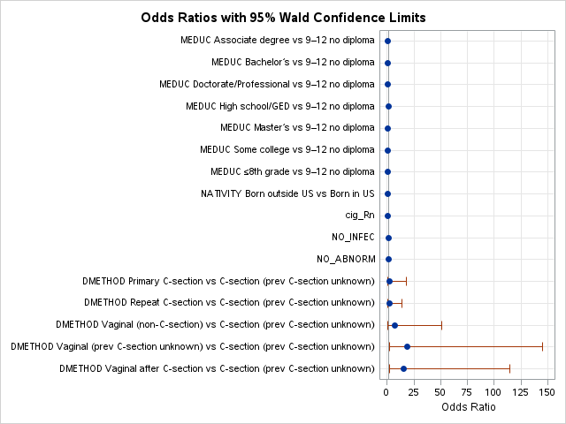

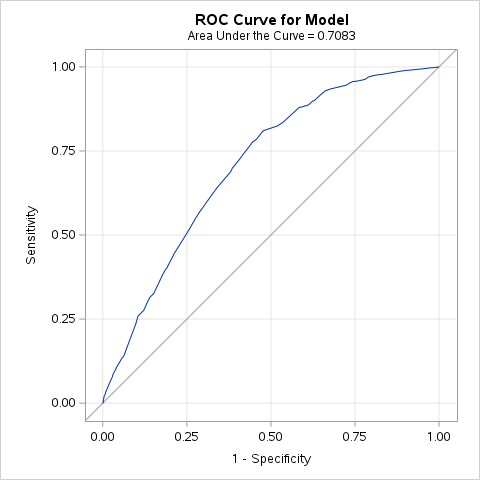

ROC Model: ROC1

| Model Convergence Status |
| --- |
| Convergence criterion (GCONV=1E-8) satisfied. |

| -2 Log L | = | 69904.636 |
| --- | --- | --- |

| Analysis of Maximum Likelihood Estimates Parameter | Analysis of Maximum Likelihood Estimates DF | Analysis of Maximum Likelihood Estimates Estimate | Analysis of Maximum Likelihood Estimates Standard Error | Analysis of Maximum Likelihood Estimates Wald Chi-Square | Analysis of Maximum Likelihood Estimates Pr > ChiSq |
| --- | --- | --- | --- | --- | --- |
| Intercept | 1 | -4.5498 | 0.0127 | 128884.972 | <.0001 |

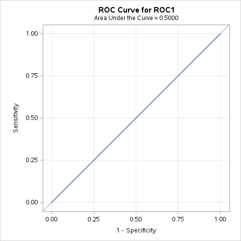

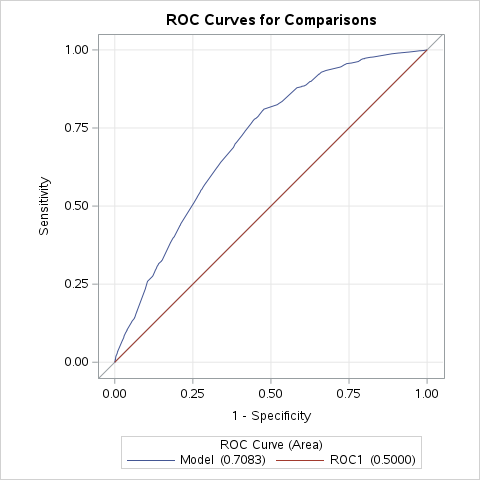

[output not shown]